# Label-free Quantification Proteomics

Data processing and QC

Tom Smith

2022-09-16

## Preamble

Label-Free Quantification (LFQ) is the simplest form of quantitative proteomics, in which different samples are quantified in separate MS runs.

Since each sample is run separately, different peptides will be quantified in each sample and the peptide intensities may not be directly comparable between samples. One solution to the higher burden of missing values is ‘match-between-runs’ (Cox et al. 2014), or the functionally equivalent ‘Minora’ algorithm employed by Proteome Discoverer (PD). These algorithms use the observed retention times of MS1 ions which were successfully spectrum matched in one sample to identify the likely peptide sequence of MS1 ions that could not be spectrum matched in another sample.

Despite the pitfalls of LFQ, the data analysis is still relatively straightforward, though there are steps that need some careful consideration and quality control assessment.

#### Load dependencies

Load the required libraries.

```r
library(ggplot2)
library(MSnbase)
library(biobroom)
library(camprotR)
library(Proteomics.analysis.data)
library(dplyr)
library(tidyr)
```

## Input data

We start with the peptide-level output from PD. We recommend staring from peptide-level PD output for LFQ data, as this will allow you to perform QC at the peptide-level and then summarise to protein-level abundance in a more appropriate manner than PD does by default, which is to simply sum all PSMs passing filters.

The data we are using are from an experiment designed to identify RNA-binding proteins (RBPs) in the U-2 OS cell line using the OOPS method (Queiroz et al. 2019). A comparison of RNase +/- is used to separate RBPs from background non-specific proteins. Four replicate experiments were performed, with the RNase +/- experiments performed from the same OOPS interface. For each LFQ run, approximately the same quantity of peptides were injected, based on quantification of peptide concentration post trypsin digestion. This data has not published but the aim of the experiment is equivalent to Figure 2e in the original OOPS paper.

The data we will use is available through the `Proteomics.analysis.data` package.

```r
pep_data <- read.delim(
  system.file("extdata", 'OOPS_RNase_LFQ', 'LFQ_OOPS_RNase_PeptideGroups.txt',
              package = "Proteomics.analysis.data"))
```

We can explore the structure of the input data using `str`. We see that we have a `data.frame` with 7808 rows and 41 columns. The most important columns to us are:

- **Sequence**: The sequence of the peptide
- **Modifications**: The detected peptide modifications, including variable, e.g induced modifications such as oxidation
- **Master.Protein.Accessions**: The assigned master protein(s)
- **Abundance.F*.Sample**: Columns with the peptide intensities

```r
str(pep_data)
```

```
#> 'data.frame':    7808 obs. of  41 variables:
#>  $ Peptide.Groups.Peptide.Group.ID                      : int  3 103128 103062 103059 103056 103049 103048 103045 102936 102916 ...
#>  $ Checked                                              : chr  "False" "False" "False" "False" ...
#>  $ Confidence                                           : chr  "High" "High" "High" "High" ...
#>  $ Sequence                                             : chr  "AAAAAAAAAAAAAAAGAGAGAK" "LVKPGNQNTQVTEAWNK" "LVGSVNLFSDENVPR" "LVGSQEELASWGHEYVR" ...
#>  $ Modifications                                        : chr  "" "" "" "" ...
#>  $ Qvality.PEP                                          : num  4.27e-07 8.31e-04 1.36e-03 7.92e-04 1.87e-06 ...
#>  $ Qvality.q.value                                      : num  0.00026 0.00026 0.00026 0.00026 0.00026 ...
#>  $ Number.of.Protein.Groups                             : int  1 1 1 1 1 1 1 1 1 1 ...
#>  $ Number.of.Proteins                                   : int  1 1 1 1 1 1 1 1 1 1 ...
#>  $ Number.of.PSMs                                       : int  8 8 4 8 16 7 26 12 10 11 ...
#>  $ Master.Protein.Accessions                            : chr  "P55011" "Q9UQ80" "Q9BQG0" "Q13200" ...
#>  $ Protein.Accessions                                   : chr  "P55011" "Q9UQ80" "Q9BQG0" "Q13200" ...
#>  $ Number.of.Missed.Cleavages                           : int  0 0 0 0 0 1 0 0 0 1 ...
#>  $ Theo.MHplus.in.Da                                    : num  1597 1927 1646 1960 1515 ...
```

[output cut: 27 more lines]

### Discussion 1

> Examine the column names and answer the following:

> How do the numerical values in the Abundance.F*.Sample columns relate to the conditions (RNase +/-)?

> Solution

```r
# It's not possible to tell!
```

> Solution end

The `InputFiles.txt` file from PD can be used to determine the relationship between the Abundance.F*.Sample columns and the samples. If you are in any doubt, you can also check with the Proteomics Facility.

The accompanying `LFQ_OOPS_RNase_InputFiles.txt` file is also available through the `Proteomics.analysis.data` package.

```r
inputfiles <- read.delim(
  system.file("extdata", 'OOPS_RNase_LFQ', 'LFQ_OOPS_RNase_InputFiles.txt',
              package = "Proteomics.analysis.data"))
print(inputfiles %>% filter(Study.File.ID!=''))
```

```
#>   Input.Files.Workflow.ID Input.Files.Workflow.Level Input.Files. Study.File.ID
#> 1                    -177                          1           55           F17
#> 2                    -180                          1           40           F18
#> 3                    -183                          1           42           F19
#> 4                    -186                          1           44           F20
#> 5                    -189                          1           46           F21
#> 6                    -192                          1           48           F22
#> 7                    -195                          1           50           F23
#> 8                    -198                          1           52           F24
#>                                                                File.Name
#> 1      Z:\\RAW\\rq214\\LFQ_RNase_test_Jan2020\\R_neg_MetChloroform_1.raw
#> 2      Z:\\RAW\\rq214\\LFQ_RNase_test_Jan2020\\R_neg_MetChloroform_2.raw
#> 3      Z:\\RAW\\rq214\\LFQ_RNase_test_Jan2020\\R_neg_MetChloroform_3.raw
#> 4      Z:\\RAW\\rq214\\LFQ_RNase_test_Jan2020\\R_neg_MetChloroform_4.raw
#> 5 Z:\\RAW\\rq214\\LFQ_RNase_test_Jan2020\\R_positive_MetChloroform_1.raw
#> 6 Z:\\RAW\\rq214\\LFQ_RNase_test_Jan2020\\R_positive_MetChloroform_2.raw
#> 7 Z:\\RAW\\rq214\\LFQ_RNase_test_Jan2020\\R_positive_MetChloroform_3.raw
#> 8 Z:\\RAW\\rq214\\LFQ_RNase_test_Jan2020\\R_positive_MetChloroform_4.raw
#>           Creation.Date RT.Range.in.min  Instrument.Name Software.Revision
#> 1  2/17/2020 2:02:44 AM   40.00 - 90.00 Orbitrap Eclipse       3.3.2782.34
#> 2  2/17/2020 3:34:26 AM   40.00 - 90.00 Orbitrap Eclipse       3.3.2782.34
#> 3  2/17/2020 5:06:10 AM   40.00 - 90.00 Orbitrap Eclipse       3.3.2782.34
#> 4  2/17/2020 6:37:53 AM   40.00 - 90.00 Orbitrap Eclipse       3.3.2782.34
#> 5 2/17/2020 11:42:55 AM   40.00 - 90.00 Orbitrap Eclipse       3.3.2782.34
#> 6  2/17/2020 1:14:33 PM   40.00 - 90.00 Orbitrap Eclipse       3.3.2782.34
#> 7  2/17/2020 2:46:16 PM   40.00 - 90.00 Orbitrap Eclipse       3.3.2782.34
#> 8  2/17/2020 4:17:54 PM   40.00 - 90.01 Orbitrap Eclipse       3.3.2782.34
```

Here, we see that F17-20 are ‘R_neg’, e.g RNase - and F21-24 are ‘R_positive’, e.g RNase +.

We could parse the `InputFiles.txt` file to generate the sample information, but for this experiment, it’s small enough that it can be easily generated manually.

```r
sample_data <- data.frame(
  File = paste0("F", 17:24),
  Sample = paste0(rep(c("RNase_neg", "RNase_pos"), each = 4), ".", 1:4),
  Condition = rep(c("RNase_neg", "RNase_pos"), each = 4),
  Replicate = rep(1:4, 2)
)

# Displaying the table in a nicer format
knitr::kable(sample_data,
             align = "cccc",
             format = "html",
             table.attr = "style='width:30%;'")
```

| File | Sample | Condition | Replicate |
| --- | --- | --- | --- |
| F17 | RNase_neg.1 | RNase_neg | 1 |
| F18 | RNase_neg.2 | RNase_neg | 2 |
| F19 | RNase_neg.3 | RNase_neg | 3 |
| F20 | RNase_neg.4 | RNase_neg | 4 |
| F21 | RNase_pos.1 | RNase_pos | 1 |
| F22 | RNase_pos.2 | RNase_pos | 2 |
| F23 | RNase_pos.3 | RNase_pos | 3 |
| F24 | RNase_pos.4 | RNase_pos | 4 |

### Parse PeptideGroups.txt file

To simplify the process of reading in the data and performing initial filtering, we will use `camprotR::parse_features`. This function will read in the data and remove contaminant proteins and features without quantification data. Contaminant proteins were defined using the [cRAP database](https://www.thegpm.org/crap/) and provided to PD. We need to obtain their accessions and provide these to `camprotR::parse_features`. Below, we parse the cRAP FASTA to extract the IDs for the cRAP proteins, in both ‘cRAP’ format and Uniprot IDs for these proteins.

The file we will use, `cRAP_20190401.fasta.gz`, is again available through the `Proteomics.analysis.data` package.

```r
crap_fasta_inf <- system.file(
  "extdata", "cRAP_20190401.fasta.gz",
  package = "Proteomics.analysis.data"
)

# Load the cRAP FASTA used for the PD search
crap_fasta <- Biostrings::fasta.index(crap_fasta_inf, seqtype = "AA")

# Extract the UniProt accessions associated with each cRAP protein
crap_accessions <- crap_fasta %>%
  pull(desc) %>%
  stringr::str_extract_all(pattern="(?<=\\|).*?(?=\\|)") %>%
  unlist()
```

We can then supply these cRAP protein IDs to `camprotR::parse_features()` which will remove features (i.e. peptides in this case) which may originate from contaminants, as well as features which don’t have a unique master protein.

See `?parse_features` for further details, including the removal of ‘associated cRAP’ for conservative contaminants removal.

```r
pep_data_flt <- camprotR::parse_features(
  pep_data,
  level = 'peptide',
  crap_proteins = crap_accessions,
)
```

```
#> Parsing features...
#> 7808 features found from 1463 master proteins => Input
#> 242 cRAP proteins supplied
#> 364 proteins identified as 'cRAP associated'
#> 7509 features found from 1414 master proteins => cRAP features removed
#> 7476 features found from 1396 master proteins => associated cRAP features removed
#> 7471 features found from 1395 master proteins => features without a master protein removed
#> 7250 features found from 1307 master proteins => features with non-unique master proteins removed
```

From the above, we can see that we have started with 7808 ‘features’ (peptides) from 1463 master proteins across all samples. After removal of contaminants and peptides that can’t be assigned to a unique master protein, we have 7250 peptides remaining from 1307 master proteins.

## Convert to MSnSet

We now store the filtered peptide data in an MSnSet, the standard data object for proteomics in R.

This object contains 3 elements:

- A quantification data matrix (rows=features, e.g peptides/proteins, columns=samples)
- Feature data (rows=features, columns=feature annotations, e.g peptide master protein assignment)
- Experimental details (rows=samples, columns=experimental details, e.g treatment)

See the `vignette("msnset", package="camprotR")` for more details.

```r
# Create expression matrix with peptide abundances (exprs) and
# human readable column names
exprs_data <- pep_data_flt %>%
  select(matches("Abundance")) %>%
  setNames(sample_data$Sample) %>%
  as.matrix()

# Create data.frame with sample metadata (pData)
pheno_data <- sample_data %>%
  select(-File) %>%
  tibble::column_to_rownames(var = "Sample")

# Create data.frame with peptide metadata (fData)
feature_data <- pep_data_flt %>%
  select(-matches("Abundance"))

# Create MSnSet
pep <- MSnbase::MSnSet(exprs = exprs_data,
                       fData = feature_data,
                       pData = pheno_data)
```

## QC peptides

First of all, we want to inspect the peptide intensity distributions.

### Exercise 1

> Plot the distributions of intensities for each sample. What do you conclude?

> Hints:
> - You can access the assay data using `exprs(pep)`
> - You will need to log-transform the abundances to make them interpretable

> Solution

```r
log(pep, base=2) %>% exprs() %>% boxplot()
```

> Solution end

The above code give us a crude representation. We could make this prettier, but `camprotR` already has a function to explore the quantification distributions, `plot_quant`, which we can use instead. Below, we plot boxplots and density plot to inspect the abundance distributions.

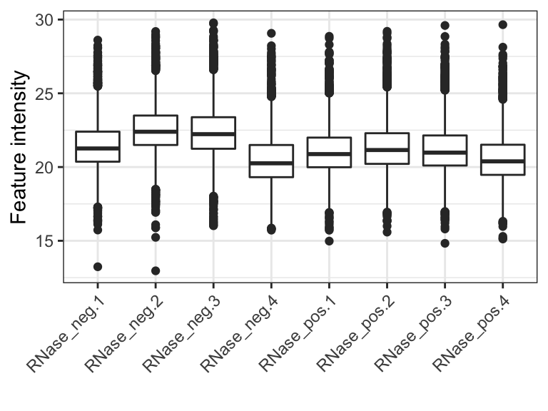

Peptide intensities

```r
pep %>%
  log(base = 2) %>%
  camprotR::plot_quant(method = 'box')
```

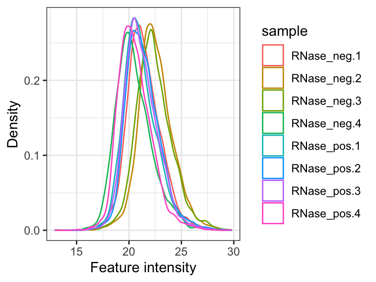

Peptide intensities

```r
pep %>%
  log(base = 2) %>%
  camprotR::plot_quant(method = 'density')
```

We expect these to be approximately equal and any very low intensity sample would be a concern that would need to be further explored. Here, we can see that there is some clear variability, but no sample with very low intensity.

## Missing values

Next, we consider the missing values, using `MSnbase::plotNA` to give us a quick graphical overview. This function shows the number of features with each level of data completeness (‘Individual features’) and the overall proportion of missing values in the dataset (Full dataset). The number of features with an acceptable level of missingness (specified by `pNA`) is also highlighted on the plot.

Note that `MSnbase::plotNA` assumes the object contains protein-level data and names the x-axis accordingly. Here, we update the plot aesthetics and rename the x-axis.

```r
p <- MSnbase::plotNA(pep, pNA = 0) +
  camprotR::theme_camprot(border = FALSE, base_family = 'sans', base_size = 10) +
  labs(x = 'Peptide index')
```

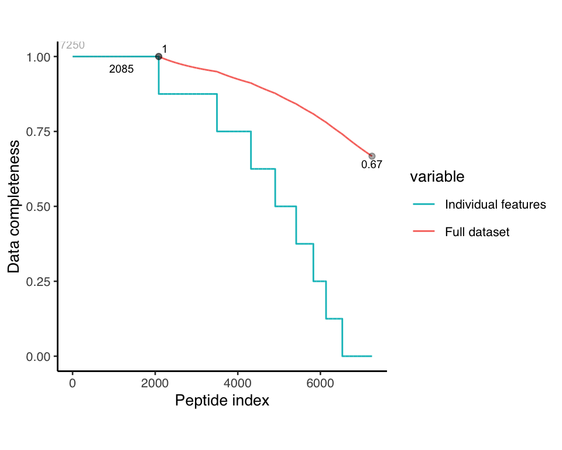

Peptide-level data completeness

```r
print(p)
```

### Exercise 2

> Hint: You can use `is.na` directly on the `MSnSet` and it is equivalent to calling `is.na(exprs(obj))`

> Solution

```r
sum(is.na(pep)) #1
```

```
#> [1] 19289
```

```r
mean(is.na(pep)) #2
```

```
#> [1] 0.332569
```

```r
colSums(is.na(pep)) #3
```

```
#> RNase_neg.1 RNase_neg.2 RNase_neg.3 RNase_neg.4 RNase_pos.1 RNase_pos.2
#>        1901        2001        1897        3542        2580        2504
#> RNase_pos.3 RNase_pos.4
#>        2098        2766
```

```r
sum(rowSums(is.na(pep))==0) #4
```

```
#> [1] 2085
```

> Solution end

So, from the 7250 peptides, just 2085 have quantification values in all 8 samples. This is not a surprise for LFQ, since each sample is prepared and run separately.

We can also explore the structure of the missing values further using an ‘upset’ plot. Here, we use the `naniar` package for this.

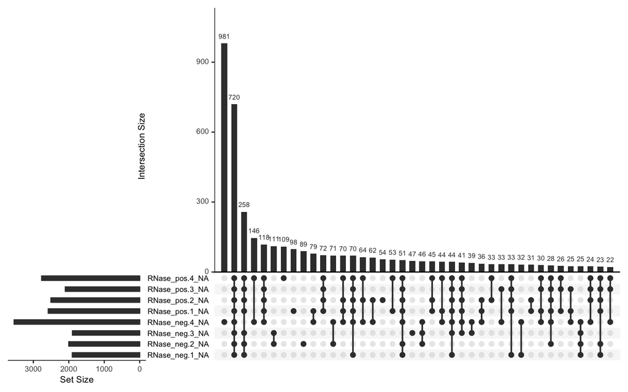

Missing values upset plot

```r
missing_data <- pep %>%
  exprs() %>%
  data.frame()

naniar::gg_miss_upset(missing_data,
                      sets = paste0(colnames(pep), '_NA'),
                      keep.order = TRUE,
                      nsets = 10)
```

RNase negative replicate 4 had slightly lower overall peptide intensities and appears to be somewhat of an outlier. In this case, we will retain the sample but in other cases, this may warrant further exploration and potentially removal of a sample.